# Examining the coevolution of friendships and political orientation using SAOM

Astrid Skjold

Due 12/21/2021

What is the relationship between the friendships and political orientations of university students? Do students’ friendships influence their political orientation? Or is political orientation a basis for students’ choice of friends? This blog post examines the co-evolution of the two, as well as potential structural, individual, and dyadic determinants. The aim is to empirically explore the relationship between the social influence on people via friendships, and changes in political views. Using the NetSense dataset on students entering the University of Notre Dame, the report estimates and runs a Stochastic Actor-Oriented Model (SAOM) to evaluate the following two hypotheses:

H1: The more liberal(conservative) one’s friends, the more liberal(conservative) one becomes  
H2: One is more likely to become friends with someone who shares one’s political views

The hypotheses are motivated by the desire to disentangle influence and selection; whether people select friends that share their political views, or whether their friends influence their political views, see e.g., [Lazer et al. 2010](https://www.tandfonline.com/doi/abs/10.1080/10584609.2010.500187), [Wang et al. (2020)](https://journals.plos.org/plosone/article?id=10.1371/journal.pone.0233458). The report takes advantage of SAOMs’ ability to, in one model, estimate the effects of influence, selection, network structures, and nodal attributes [Block et al. 2016](https://journals.sagepub.com/doi/full/10.1177/0049124116672680).

## DATA

The data used is taken from [Wang et al. (2020)](https://journals.plos.org/plosone/article?id=10.1371/journal.pone.0233458), who have adapted the NetSense Study and studied the same using SAOMs. The data contains information on friendships (directed, unweighted), political orientation (Likert scale from extremely liberal to extremely conservative), as well as a range of monadic and dyadic nodal attributes. This report examines the following attributes: shared residential hall (ResidentialHall), shared religion(Religion), the income of a student’s parents (ParentsIncome), gender(Gender), and the extent to which the student has political discussions with others (Political Discussion). The data includes 196 nodes and 4 waves (Semesters 1, 2, 3, and 4). There are no missing nodes.

```r
library(migraph)
library(igraph)
library(RSiena)
```

```r
load("netsense.rda")
```

## VISUALIZING THE NETWORKS

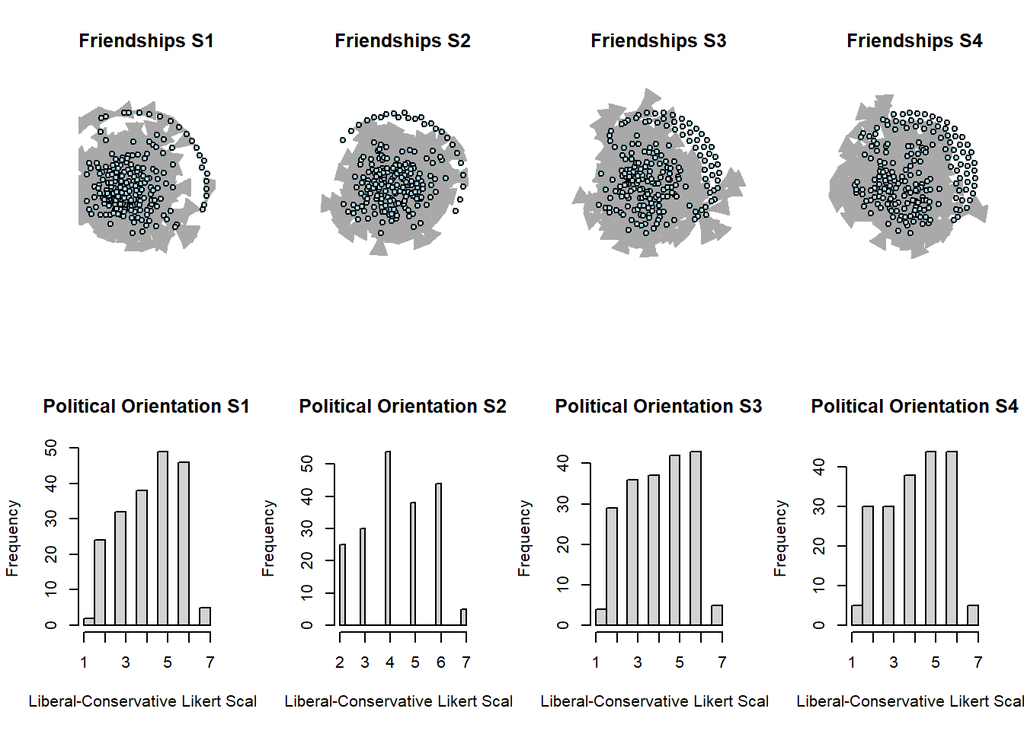

```r
friendship1 <- mydata$depvars$friendship[,,1]
friendship2 <- mydata$depvars$friendship[,,2]
friendship3 <- mydata$depvars$friendship[,,3]
friendship4 <- mydata$depvars$friendship[,,4]

polview1 <- mydata$depvars$polview[,,1]
polview2 <- mydata$depvars$polview[,,2]
polview3 <- mydata$depvars$polview[,,3]
polview4 <- mydata$depvars$polview[,,4]

graph1 <- graph.adjacency(friendship1, mode="directed")
graph2 <- graph.adjacency(friendship2, mode="directed")
graph3 <- graph.adjacency(friendship3, mode="directed")
graph4 <- graph.adjacency(friendship4, mode="directed")

par(mfrow = c(2,4))
plot(graph1, vertex.label=NA, main="Friendships S1", vertex.size = 10, vertex.color = "lightblue")
plot(graph2, vertex.label=NA, main="Friendships S2", vertex.size = 10, vertex.color = "lightblue")
plot(graph3, vertex.label=NA, main="Friendships S3", vertex.size = 10, vertex.color = "lightblue")
plot(graph4, vertex.label=NA, main="Friendships S4", vertex.size = 10, vertex.color = "lightblue")
hist(polview1, breaks=20, main="Political Orientation S1", xlab="Liberal-Conservative Likert Scale")
hist(polview2, breaks=20, main="Political Orientation S2", xlab="Liberal-Conservative Likert Scale")
hist(polview3, breaks=20, main="Political Orientation S3", xlab="Liberal-Conservative Likert Scale")
hist(polview4, breaks=20, main="Political Orientation S4", xlab="Liberal-Conservative Likert Scale")
```

## MODEL SPECIFICATIONS AND ESTIMATION

The model includes the following effects:

Structural effects: Outdegree density, transitivity (GWESP I -> K -> J (69)), reciprocity  
Actor attributes (monadic, constant): gender, parental income  
Actor attributes (monadic, time-varying): political view, political discussion  
Actor attributes (dyadic, constant): residential hall, religion, shared gender

```r
# Creating SIENA objects
friendships <- sienaDependent(array(c(friendship1, friendship2, friendship3, friendship4), dim = c(196, 196, 4) ),
                       type="oneMode")
polview <- sienaDependent(mydata$depvars$polview,
                            type="behavior")
ParentIncome <- coCovar(as.vector(mydata$cCovars$parincome))
Gender <- coCovar(as.vector(mydata$cCovars$female))
PoliticalDiscussion <- varCovar(mydata$vCovars$dispol)
ResidentialHall <- coDyadCovar(mydata$dycCovars$reshall)
Religion <- coDyadCovar(mydata$dycCovars$religion)

FriendPolviewData <- sienaDataCreate(friendships, polview,
                              ParentIncome, Gender, PoliticalDiscussion,
                              ResidentialHall, Religion)

print01Report(FriendPolviewData, modelname = 'FriendPolViewResults')

# Specifying the model with effects
FriendPolViewEff <- getEffects(FriendPolviewData)

effectsDocumentation(FriendPolViewEff, type="html", display = T)

FriendPolViewEff <- includeEffects(FriendPolViewEff, egoX,altX,simX, interaction1 = 'polview')
```

```
##   effectName         include fix   test  initialValue parm
## 1 polview alter      TRUE    FALSE FALSE          0   0
## 2 polview ego        TRUE    FALSE FALSE          0   0
## 3 polview similarity TRUE    FALSE FALSE          0   0
```

```r
FriendPolViewEff <- includeEffects(FriendPolViewEff, egoX,altX,simX, interaction1 = 'ParentIncome')
```

```
##   effectName              include fix   test  initialValue parm
## 1 ParentIncome alter      TRUE    FALSE FALSE          0   0
## 2 ParentIncome ego        TRUE    FALSE FALSE          0   0
## 3 ParentIncome similarity TRUE    FALSE FALSE          0   0
```

```r
FriendPolViewEff <- includeEffects(FriendPolViewEff, egoX,altX,simX, interaction1 = 'Gender')
```

```
##   effectName        include fix   test  initialValue parm
## 1 Gender alter      TRUE    FALSE FALSE          0   0
## 2 Gender ego        TRUE    FALSE FALSE          0   0
## 3 Gender similarity TRUE    FALSE FALSE          0   0
```

```r
FriendPolViewEff <- includeEffects(FriendPolViewEff, egoX,altX,simX, interaction1 = 'PoliticalDiscussion')
```

```
##   effectName                     include fix   test  initialValue parm
## 1 PoliticalDiscussion alter      TRUE    FALSE FALSE          0   0
## 2 PoliticalDiscussion ego        TRUE    FALSE FALSE          0   0
## 3 PoliticalDiscussion similarity TRUE    FALSE FALSE          0   0
```

```r
FriendPolViewEff <- includeEffects(FriendPolViewEff, X, interaction1="ResidentialHall")
```

```
##   effectName      include fix   test  initialValue parm
## 1 ResidentialHall TRUE    FALSE FALSE          0   0
```

```r
FriendPolViewEff <- includeEffects(FriendPolViewEff, X, interaction1="Religion")
```

```
##   effectName include fix   test  initialValue parm
## 1 Religion   TRUE    FALSE FALSE          0   0
```

```r
FriendPolViewEff <- includeEffects(FriendPolViewEff, gwespFF)
```

```
##   effectName            include fix   test  initialValue parm
## 1 GWESP I -> K -> J (#) TRUE    FALSE FALSE          0   69
```

```r
FriendPolViewEff <- includeEffects(FriendPolViewEff, outRate, name = "polview", type = "rate", interaction1="friendships")
```

```
##   effectName                       include fix   test  initialValue parm
## 1 outdegree effect on rate polview TRUE    FALSE FALSE          0   0
```

```r
FriendPolViewEff <- includeEffects(FriendPolViewEff, inRate, name = "polview", type = "rate", interaction1="friendships")
```

```
##   effectName                      include fix   test  initialValue parm
## 1 indegree effect on rate polview TRUE    FALSE FALSE          0   0
```

```r
FriendPolViewEff <- includeEffects(FriendPolViewEff, recipRate, name = "polview", type = "rate", interaction1="friendships")
```

```
##   effectName                          include fix   test  initialValue parm
## 1 reciprocated effect on rate polview TRUE    FALSE FALSE          0   0
```

```r
#Estimating the model
model1 <- sienaAlgorithmCreate(projname = "FriendPolViewResults",
                                modelType = c(friendships=1), n3=1000)
```

```
## If you use this algorithm object, siena07 will create/use an output file FriendPolViewResults.txt .
```

```r
sienaConverge <- function(alg, dat, eff, cpu=2, new.converge=T){
  numr <- 0
  ans <- siena07(alg, data=dat, effects=eff,
                 batch=T, useCluster=T, nbrNodes=cpu, initC=T,
                 returnDeps=T)
  repeat {
    numr <- numr+1
    cat("Run:", numr, "tmax:", ans$tmax, "tconv.max:", ans$tconv.max, "\n", sep = "\t")

    if (ans$tmax <= 0.1 & new.converge==F) {break}

    if (ans$tmax <= 0.1 & new.converge==T) {
      if (ans$tconv.max <= 0.25) {break} # success
      alg$doubleAveraging <- 0
      # alg$firstg <- alg$firstg/2
      if(alg$diagonalize > 0.4) alg$diagonalize <- alg$diagonalize-0.2
      alg$nsub <- 6

      probs <- cbind(ans$requestedEffects$effectName[round((solve(ans$msf) %*% apply(ans$sf,2,mean)) *
                                                             sqrt(diag(ans$msf)), 1)>2],
                     round((solve(ans$msf) %*% apply(ans$sf,2,mean)) *
                             sqrt(diag(ans$msf)), 1)[round((solve(ans$msf) %*% apply(ans$sf,2,mean)) *
                                                             sqrt(diag(ans$msf)), 1)>2])
      if (nrow(probs) > 0) {
        cat("Potentially problematic combinations of effects: \n")

        for(i in 1:nrow(probs)){
          cat(probs[i,1], probs[i,2], sep="\t")
          cat("\n")
        }
      }
    }

    # if (numr >= max.new & ans$tmax <= 0.1)  {break} # last resort, less stringent convergence criteria

    if (ans$tmax > 5)    {break} # divergence
    if (numr > 100)  {break} # too many trials

    ans <- siena07(alg, data=dat, effects=eff,
                   batch=T, useCluster=T, nbrNodes=cpu, initC=T,
                   prevAns=ans, returnDeps=T)
  }
  ans
}
```

```r
ans1 <- sienaConverge(model1, dat = FriendPolviewData, eff = FriendPolViewEff, cpu=6)
```

[output not shown]

[output cut: 62 more lines]

[output not shown]

```r
ans1
```

```
## Estimates, standard errors and convergence t-ratios
##
##                                                 Estimate   Standard   Convergence
##                                                              Error      t-ratio
## Network Dynamics
##    1. rate constant friendships rate (period 1) 14.8498  ( 1.2025   )   -0.0100
##    2. rate constant friendships rate (period 2)  9.9571  ( 1.3269   )    0.0211
##    3. rate constant friendships rate (period 3)  6.2712  ( 0.7201   )    0.0144
##    4. eval outdegree (density)                  -5.8546  ( 0.2530   )    0.0024
##    5. eval reciprocity                           6.8191  ( 0.3905   )   -0.0097
##    6. eval GWESP I -> K -> J (69)                0.9961  ( 0.0841   )   -0.0193
##    7. eval ResidentialHall                       0.7330  ( 0.1135   )    0.0244
##    8. eval Religion                              0.2001  ( 0.0754   )   -0.0145
##    9. eval ParentIncome alter                    0.0296  ( 0.0352   )   -0.0283
##   10. eval ParentIncome ego                     -0.1126  ( 0.0472   )    0.0150
##   11. eval ParentIncome similarity               0.1532  ( 0.1641   )    0.0062
##   12. eval Gender alter                          0.0856  ( 0.1453   )   -0.0626
##   13. eval Gender ego                            0.1119  ( 0.1485   )   -0.0261
##   14. eval Gender similarity                    -0.0258  ( 0.0693   )   -0.0405
##   15. eval polview alter                        -0.0430  ( 0.0496   )   -0.0249
##   16. eval polview ego                           0.0829  ( 0.0517   )   -0.0054
##   17. eval polview similarity                    0.2672  ( 0.2047   )   -0.0272
##   18. eval PoliticalDiscussion alter             0.2589  ( 0.0585   )    0.0307
##   19. eval PoliticalDiscussion ego              -0.1215  ( 0.0677   )    0.0168
##   20. eval PoliticalDiscussion similarity        0.1126  ( 0.1499   )   -0.0548
##
## Behavior Dynamics
##   21. rate rate polview (period 1)               1.1663  ( 0.4443   )   -0.0006
##   22. rate rate polview (period 2)               0.9203  ( 0.3076   )    0.0304
##   23. rate rate polview (period 3)               0.6772  ( 0.2443   )   -0.0012
##   24. rate outdegree effect on rate polview      0.3748  ( 0.6723   )    0.0207
##   25. rate indegree effect on rate polview      -0.1654  ( 1.3793   )    0.0303
##   26. rate reciprocated effect on rate polview  -0.2421  ( 1.4140   )    0.0228
##   27. eval polview linear shape                 -0.0727  ( 0.0592   )    0.0093
##   28. eval polview quadratic shape              -0.0876  ( 0.0367   )    0.0237
##
## Overall maximum convergence ratio:    0.1927
##
##
## Total of 2256 iteration steps.
```

```r
max(abs(ans1$tconv[!ans1$effects$fix[ans1$effects$requested]]))
```

```
## [1] 0.06261071
```

The overall maximum convergence ratio is below 0.25 and the convergence t-ratio is below 0.1 for all parameters. We can say that the model has converged.

## RESULTS

```r
siena.table(ans1)
```

```
## Results for ans1 written to ans1.tex .
```

```r
xtable(ans1, type = "html", file = "results.html")
library(texreg)
screenreg(ans1, single.row = T)
```

```
##
## ========================================================
##                                       Model 1
## --------------------------------------------------------
## constant friendships rate (period 1)    14.85 (1.20) ***
## constant friendships rate (period 2)     9.96 (1.33) ***
## constant friendships rate (period 3)     6.27 (0.72) ***
## outdegree (density)                     -5.85 (0.25) ***
## reciprocity                              6.82 (0.39) ***
## GWESP I -> K -> J (69)                   1.00 (0.08) ***
## ResidentialHall                          0.73 (0.11) ***
## Religion                                 0.20 (0.08) **
## ParentIncome alter                       0.03 (0.04)
## ParentIncome ego                        -0.11 (0.05) *
## ParentIncome similarity                  0.15 (0.16)
## Gender alter                             0.09 (0.15)
## Gender ego                               0.11 (0.15)
## Gender similarity                       -0.03 (0.07)
## polview alter                           -0.04 (0.05)
## polview ego                              0.08 (0.05)
## polview similarity                       0.27 (0.20)
## PoliticalDiscussion alter                0.26 (0.06) ***
## PoliticalDiscussion ego                 -0.12 (0.07)
## PoliticalDiscussion similarity           0.11 (0.15)
## rate polview (period 1)                  1.17 (0.44) **
## rate polview (period 2)                  0.92 (0.31) **
## rate polview (period 3)                  0.68 (0.24) **
## outdegree effect on rate polview         0.37 (0.67)
## indegree effect on rate polview         -0.17 (1.38)
## reciprocated effect on rate polview     -0.24 (1.41)
## polview linear shape                    -0.07 (0.06)
## polview quadratic shape                 -0.09 (0.04) *
## --------------------------------------------------------
## Iterations                            2256
## ========================================================
## *** p < 0.001; ** p < 0.01; * p < 0.05
```

### Rates

We see that changes in friendships were much higher in the first period than in the following two periods. The rate of change in political views is generally low, and it similarly lowers over time.

### Evaluation

Evaluation functions can be tested using the t-statistic, as described in the [Siena Manual p. 77](https://www.stats.ox.ac.uk/~snijders/siena/RSiena_Manual.pdf), by dividing the estimate by its standard error. If the absolute value is larger than 2, it is statistically significant at 0.05 significance level.

```r
t.statistic <- ans1$theta/ans1$se
t.statistic
```

```
##  [1]  12.3491858   7.5038545   8.7083620 -23.1422034  17.4626736  11.8409865
##  [7]   6.4603659   2.6538381   0.8402222  -2.3865894   0.9336854   0.5895429
## [13]   0.7534143  -0.3725799  -0.8667533   1.6024909   1.3054333   4.4277567
## [19]  -1.7943681   0.7512634   2.6252198   2.9919150   2.7718691   0.5574014
## [25]  -0.1199218  -0.1712081  -1.2287493  -2.3854013
```

```r
Effect <- c("constant friendship rate (period 1)", "constant friendship rate (period 2)", "constant friendship rate (period 3)",
            "Outdegree(density)", "Reciprocity", "GWESP I -> K -> J (69)", "ResidentialHall",
            "Religion", "ParentIncome alter", "ParentIncome ego", "ParentIncome similarity",
            "Gender alter", "Gender ego", "Gender similarity", "polview alter", "polview ego",
            "polview similarity", "PoliticalDiscussion alter", "PoliticalDiscussion ego", "PoliticalDiscussion similarity",
            "rate polview (period 1)", "rate polview (period 2)", "rate polview (period 3", "outdegree effect on rate polview",
            "indegree effect on rate polview", "reciprocated effect on rate polview", "polview liear shape",
            "polview quadratic shape")

df <- data.frame(Effect, t.statistic)
df
```

```
##                                 Effect t.statistic
## 1  constant friendship rate (period 1)  12.3491858
## 2  constant friendship rate (period 2)   7.5038545
## 3  constant friendship rate (period 3)   8.7083620
## 4                   Outdegree(density) -23.1422034
## 5                          Reciprocity  17.4626736
## 6               GWESP I -> K -> J (69)  11.8409865
## 7                      ResidentialHall   6.4603659
## 8                             Religion   2.6538381
## 9                   ParentIncome alter   0.8402222
## 10                    ParentIncome ego  -2.3865894
## 11             ParentIncome similarity   0.9336854
## 12                        Gender alter   0.5895429
## 13                          Gender ego   0.7534143
## 14                   Gender similarity  -0.3725799
## 15                       polview alter  -0.8667533
## 16                         polview ego   1.6024909
## 17                  polview similarity   1.3054333
## 18           PoliticalDiscussion alter   4.4277567
## 19             PoliticalDiscussion ego  -1.7943681
## 20      PoliticalDiscussion similarity   0.7512634
## 21             rate polview (period 1)   2.6252198
## 22             rate polview (period 2)   2.9919150
## 23              rate polview (period 3   2.7718691
## 24    outdegree effect on rate polview   0.5574014
## 25     indegree effect on rate polview  -0.1199218
## 26 reciprocated effect on rate polview  -0.1712081
## 27                 polview liear shape  -1.2287493
## 28             polview quadratic shape  -2.3854013
```

### Hypotheses evaluation

Evidence for friendship influence on political view and friendship selection based on political view is not found. We therefore reject both hypotheses.

## DIAGNOSING THE MODEL

```r
adjList1 <- ans1$sims[[1]]$Data1$friendship1$`1`
adjList <- list(list())
for(i in 1:196){
  adjList[[i]] <- adjList1[adjList1[,1] == i, 2]
}
simGraph <- graph.adjlist(adjList, mode="all")
V(simGraph)$mydata$depvars$friendship <- ans1$sims[[1]]$Data1$friendships$`1`

gofResult.outdegree <- sienaGOF(ans1, OutdegreeDistribution, varName = "friendships", verbose = TRUE)
```

[output not shown]

```r
gofResult.indegree <- sienaGOF(ans1, IndegreeDistribution, varName = "friendships", verbose = TRUE)
```

[output not shown]

```r
gofResult.behaviour <- sienaGOF(ans1, BehaviorDistribution, varName = "polview", verbose = TRUE)
```

[output not shown]

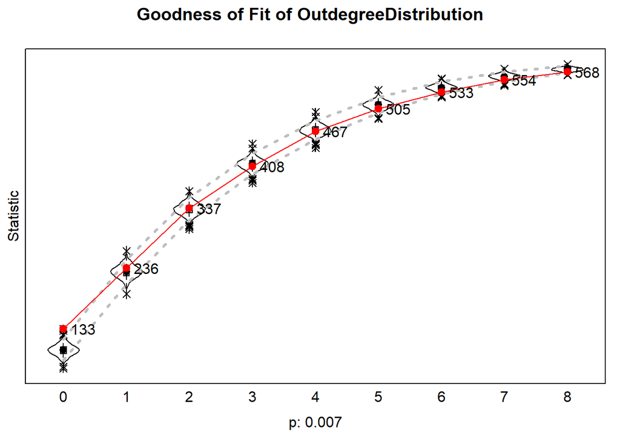

```r
plot(gofResult.outdegree)
```

```
## Note: some statistics are not plotted because their variance is 0.
## This holds for the statistic: 7.
```

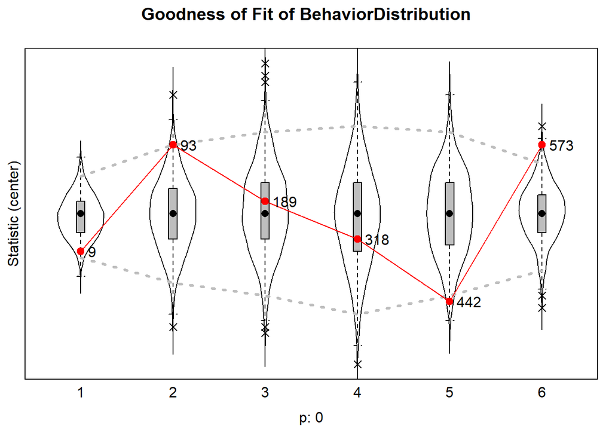

```r
plot(gofResult.behaviour, center = T)
```

```r
gofResult.behaviour
```

```
## Siena Goodness of Fit ( BehaviorDistribution ), all periods
## =====
## Monte Carlo Mahalanobis distance test p-value:  0
## **Note: Only 6 statistics are necessary in the auxiliary function.
## -----
## One tailed test used  (i.e. estimated probability of greater distance than observation).
## -----
## Calculated joint MHD = ( 41.98 ) for current model.
```

```r
gofResult.indegree
```

```
## Siena Goodness of Fit ( IndegreeDistribution ), all periods
## =====
## Monte Carlo Mahalanobis distance test p-value:  0.566
## -----
## One tailed test used  (i.e. estimated probability of greater distance than observation).
## -----
## Calculated joint MHD = ( 40.63 ) for current model.
```

```r
gofResult.outdegree
```

```
## Siena Goodness of Fit ( OutdegreeDistribution ), all periods
## =====
## Monte Carlo Mahalanobis distance test p-value:  0.007
## -----
## One tailed test used  (i.e. estimated probability of greater distance than observation).
## -----
## Calculated joint MHD = ( 49.44 ) for current model.
```

The results of Goodness of Fit show that only the indegree metric meets the criteria of a p-value above 0.05. Outdegree and behavior both have p-values below 0.05. Therefore, the model is not a good fit.

## CONCLUSION

The results show that both hypotheses are rejected. This is in line with the findings of [Wang et al. (2020)](https://journals.plos.org/plosone/article?id=10.1371/journal.pone.0233458). The only relation between friendships and politics among the students in the survey is that those that more frequently have political discussions tend to be nominated as a friend more often. Overall, network structural factors (reciprocity and transitivity) and dyadic covariates (sharing a residential hall, sharing religion) better explain friendships in the student body. An interesting extension that could be further explored is whether there are differences between people based on how politically concerned they are, such as differences between those that identify their beliefs as ‘extremely liberal/conservative’ and those with more moderate views.